# PA1_template

## For the next analysis, repeat the original histogram but using the new dataset with no missing values

### 1. Calculate total daily steps in order to produce histogram and determine mean and median values.

```r
steps_sum2 <- aggregate(steps ~ date, steps_complete, sum)
```

### 2. Create a histogram of the daily total steps

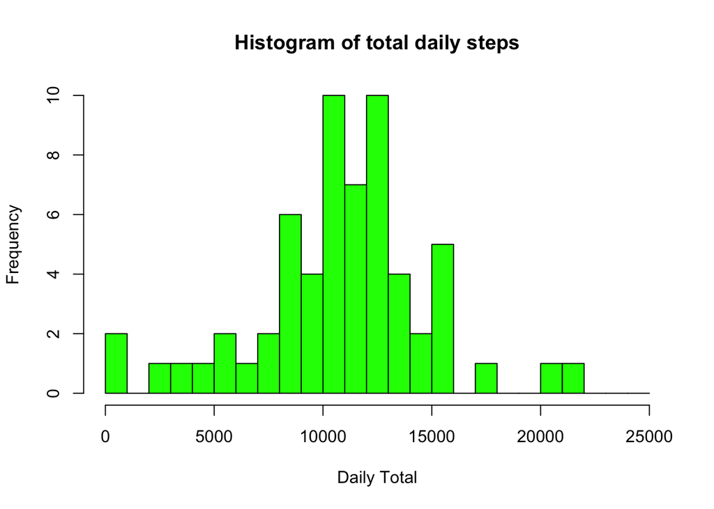

```r
hist(steps_sum2$steps, col="green", main = "Histogram of total daily steps",
     xlab = "Daily Total", ylab = "Frequency", breaks=seq(from=0, to=25000, by=1000))
```

## For the final analysis, construct a panel plot comparing the interval averages between weekdays and weekends

### 1. First create an additional column “typeday” set to either “weekday” or “weekend” as appropriate. This uses the mutate function so we first load the dplyr library

```r
library(dplyr)
steps_complete <- mutate(steps_complete, typeday = ifelse(steps_complete$weekday=="Saturday" | steps_complete$weekday=="Sunday", "weekend", "weekday"))
steps_complete$typeday <- as.factor(steps_complete$typeday)
```

### 2. Construct a panel plot comparing the average steps by interval between weekdays and weekends. Load the lattice library first.

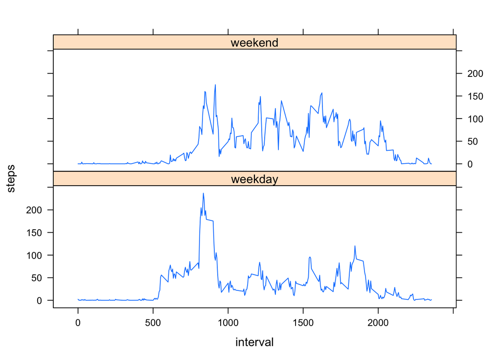

```r
library(lattice)
steps_sum3 <- aggregate(steps ~ interval + typeday, steps_complete, mean)
xyplot(steps ~ interval | typeday, data=steps_sum3, layout=c(1,2), type="l")
```